# PCA and diversity analysis

# Data preparation

Analysis is conducted on sample and comparative data where contaminants have been removed (see authentication report).

The data frame with species counts is converted to the appropriate format with one sample per row, and one column per taxon

Metadata for the included samples are prepared,

and for samples from this study only.

Data are converted to a matrix in *04-diversity.R* for further analysis with the [**mixOmics**](http://mixomics.org/) and [**vegan**](https://cran.r-project.org/web/packages/vegan/index.html) R packages.

# Diversity

## Alpha

### Experiment duration

Shannon index across the course of the experiment.

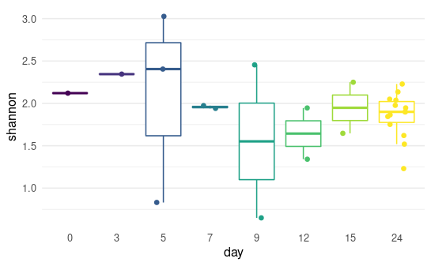

Not really enough samples to make any relevant interpretations.

Days were grouped for increased sample sizes.

- inoc = days 0,3,5
- treatment = days 7,9,12,15,18,21
- final = day 24

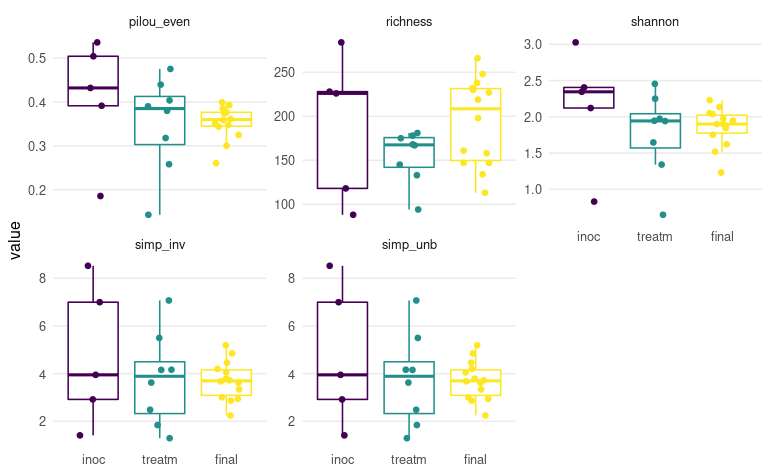

Slight decrease in Shannon diversity over the course of the experiment.

### Sample types

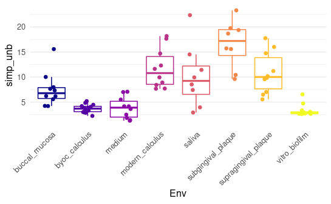

Shannon `vegan::diversity(species_otu_matrix)` and unbiased Simpson `simpson.unb(species_otu_matrix,inverse = T)`.

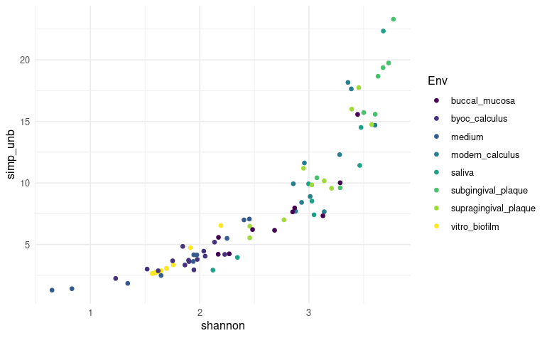

## Beta

Sparse principal components analysis (sPCA) was conducted on the experimental samples only using the **mixOmics** R package, and a separate analysis was conducted on the experimental and oral reference samples. Prior to sPCA, the sample counts underwent a centered log-ratio (CLR) transformation with +1 offset to avoid taking the log of zero.

### Experiment samples only

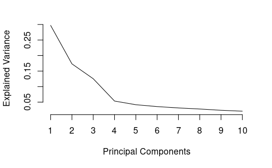

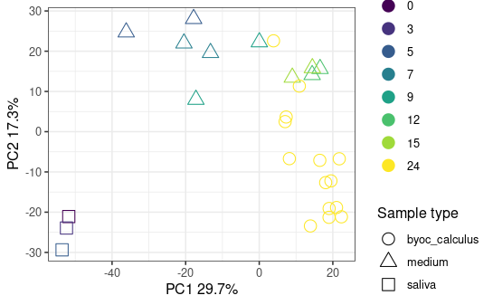

PC1 discriminates the saliva samples and early medium samples from the later medium and calculus samples, while PC2 mainly discriminates calculus from medium. Medium and final product are distinct from the saliva samples used for inoculation.

| species | PC1 | PC2 | Oxygen tolerance |
| --- | --- | --- | --- |
| Gemella sanguinis | -0.180096480 | 0.0645675660 | facultative anaerobe |
| Rothia dentocariosa | -0.153968417 | 0.0357391135 | aerobe |
| Neisseria sp. oral taxon 014 | -0.150126465 | -0.0065961354 | NA |
| Neisseria meningitidis | -0.139396840 | -0.0017356375 | facultative anaerobe |
| Neisseria mucosa | -0.137823045 | -0.0264562766 | facultative anaerobe |
| Neisseria flavescens | -0.137379452 | 0.0195763853 | aerobe |
| Neisseria elongata | -0.132954995 | -0.0213021187 | facultative anaerobe |
| Streptococcus sp. oral taxon 064 | -0.128918465 | 0.0728488751 | NA |
| Cardiobacterium hominis | -0.125265518 | -0.0246492146 | facultative anaerobe |
| Neisseria lactamica | -0.119406102 | -0.0056093110 | facultative anaerobe |

[output cut: 990 more lines]

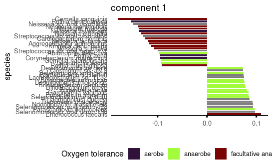

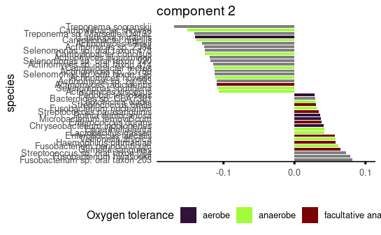

PC1 sees mostly negative loadings on aerobes and facultative anaerobes, while positive loadings are mostly anaerobes. PC2 is slightly more balanced.

### Artificial calculus and comparative oral sources

Scree plot of components.

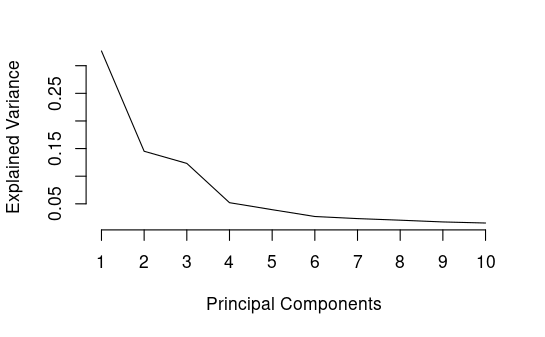

sPCA plots of PC1 on PC2 and PC1 on PC3.

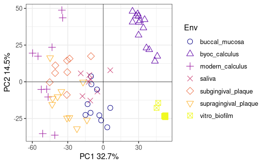

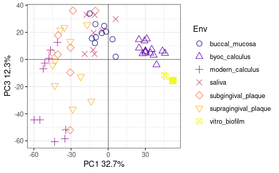

PC1 separates all artificial samples from the reference samples, while PC2 separates some modern calculus samples from other oral reference samples, as well as separating the artificial calculus from this study from the comparative *in vitro* biofilms. PC3 separates some modern calculus samples from other comparative oral samples.

Main drivers of discrimination. Top loading vectors for PC1 and PC2.

| species | PC1 | PC2 | PC3 | Oxygen tolerance |
| --- | --- | --- | --- | --- |
| Enterococcus faecalis | 1.152267e-01 | 8.176425e-02 | 0.0607428695 | facultative anaerobe |
| Enterococcus durans | 1.038127e-01 | 3.159835e-02 | 0.0185247328 | facultative anaerobe |
| Enterococcus casseliflavus | 8.993506e-02 | 2.229140e-02 | 0.0031574728 | facultative anaerobe |
| Veillonella atypica | 8.090240e-02 | -8.849748e-03 | 0.0744869660 | anaerobe |
| Enterobacter hormaechei | 6.940328e-02 | -6.060871e-02 | -0.0390438648 | aerobe |
| Lactobacillus johnsonii | 6.788300e-02 | -1.541720e-02 | 0.0132773611 | anaerobe |
| Cryptobacterium curtum | 6.519153e-02 | 8.827274e-02 | 0.0383473245 | anaerobe |
| Lactobacillus jensenii | 6.261033e-02 | -2.262846e-02 | 0.0003261929 | anaerobe |
| Veillonella dispar | 6.209382e-02 | 8.871042e-03 | 0.0741055373 | anaerobe |
| Dolosigranulum pigrum | 5.937535e-02 | -2.507873e-02 | 0.0390565350 | anaerobe |

[output cut: 990 more lines]

| species | PC1 | PC2 | PC3 | Oxygen tolerance |
| --- | --- | --- | --- | --- |
| Olsenella uli | 8.427266e-03 | 0.145231103 | -0.0159832372 | anaerobe |
| Selenomonas sputigena | -2.445528e-02 | 0.141522963 | 0.0434923657 | anaerobe |
| Selenomonas sp. oral taxon 478 | -1.063308e-02 | 0.133533710 | 0.0554448733 | NA |
| Mogibacterium diversum | 3.267375e-03 | 0.132608905 | 0.0841983036 | anaerobe |
| Selenomonas sp. oral taxon 136 | -1.166430e-02 | 0.127652766 | 0.0524160116 | NA |
| Streptococcus sp. oral taxon 064 | -1.115700e-02 | -0.118766169 | -0.0159352881 | NA |
| Prevotella oris | -3.148021e-02 | 0.117334913 | 0.0919078271 | anaerobe |
| Prevotella denticola | -2.736494e-02 | 0.108924676 | 0.0769763273 | anaerobe |
| Selenomonas sp. oral taxon 126 | -4.293516e-02 | 0.108517613 | 0.0400977696 | NA |
| Prevotella enoeca | -2.884211e-02 | 0.106416857 | 0.0833926148 | NA |

[output cut: 990 more lines]

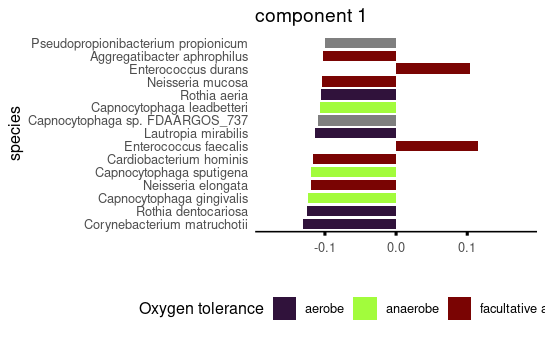

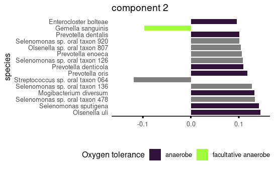

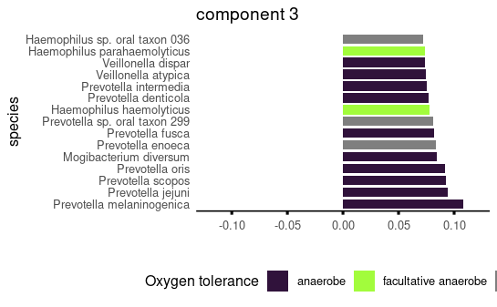

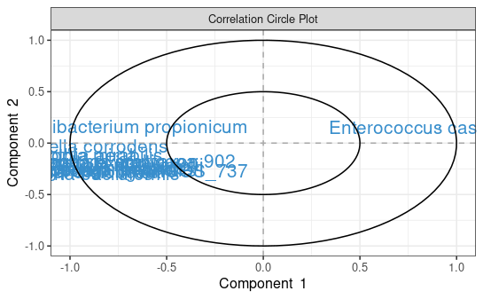

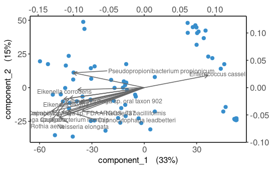

# Discussion

Main takeaway is the loss of diversity across the experiment and compared to reference samples. The donated saliva for the experiment had a lower diversity than the reference saliva samples, and may have contributed to a lower diversity in experiment samples. Community profile of artificial calculus differs from the oral reference samples, while modern calculus mostly resembles oral reference samples. The main difference between artificial and reference samples seems to be a lack of aerobes in artificial samples and a dominance by *Enterococcus* spp.